# Elections and Political Participation - lecture notes

Michał Pierzgalski

This version: October 30, 2018 (This document is a work in progress)

# References

See the **course syllabus** that is available via Moodle e-learning platform: https://moodle.uni.lodz.pl/?lang=en

https://docs.google.com/document/d/1JFKfCKntFD7IqTDogMdiQvNAYtbFWV1jnX3jewbepsQ/edit?usp=sharing

# Lecture 1: Preliminaries - Democracy and elections

# Introductory question

**What is the most fundamental feature/principle of democracy?**

# Normative and positive statements

In science, statements are broken into two main categories:

- positive, and
- normative.

# Normative and positive statements (2)

**Positive political science** is the branch of political science that concerns the description and explanation of political phenomena.

- A **positive statement** is objective and therefore can be scientifically tested for legitimacy based on available evidence. An example is, "Decreasing labor costs lead to a decrease in unemployment".
- A **normative statement** is opinion-based and subjective. An example of this: "Tax rates are unfair."

# Normative and positive statements (3)

- In contrast to positive statements, normative statements are primarily philosophical and we can make value judgments about these statements.
- Normative statements make claims about **how things should or ought to be**, how to value them, which things are good or bad, and which actions are right or wrong.

# Normative and positive statements (4)

Positive statements are **either true or false**. Before we check whether or not positive statement is true, we call it a **hypothesis**.

When a hypothesis is positively tested we can say that statement is a theorem or corollary.

# Democracy - *normative* and *positive* definitions

- *The democratic method is that institutional arrangement for arriving at political decisions which realizes the **common good** by making the people itself decide issues through the election of individuals who are to assemble in order to carry out its will*;
- *The democratic method is that institutional arrangement for arriving at political decisions in which individuals acquire the power to decide by means of a competitive struggle for the people’s vote*.

– (Schumpeter, 1976)

# Democracy

- *Democracy is a system in which political parties lose elections* (Przeworski, 1991).

# Elections

*Election* is simply a choice. To elect means “to choose or make a decision”.

- An election is a formal decision-making process by which a population chooses an individual to hold public office. Elections have been the usual mechanism by which modern *representative democracy* has operated since the 18/19th century (e.g. USA). Elections may fill offices in the legislature, in the executive and judiciary, and for regional and local government.
- Sometimes other forms of voting such as referendums are referred to as elections, especially in the United States.

# Partisan and non-partisan elections

- Nonpartisan elections - candidate is eligible based on her or his own merits rather than as a member of a political party. No political affiliation is shown on the ballot next to a candidate.
- Nonpartisan elections are common e.g.: 1) in the **election of judges** (e.g. in the U.S.), or 2) for **local government offices** such as: municipal and county offices.
- In some nonpartisan elections, it is common knowledge which candidates are backed by which parties; in others, parties are uninvolved and voters make choices with no regard to partisan considerations.

IOWA judges selection: https://www.dropbox.com/s/8nrcissdbhym9df/JNP_KnowYourCourts_2015.pdf?dl=0

# Direct and representative democracy

- **Direct** democracy - e.g. Athens in 6th century BC (Cleisthenes democratic constitution);
- **Representative** democracy - modern form of democratic government (e.g. Spain, Poland).

# Athenian democracy

- Athenian democracy took the form of a direct democracy, and it had two distinguishing features: **the random selection** of ordinary citizens to fill the few existing government administrative and judicial offices (**sortition**), and **a legislative assembly consisting of all Athenian citizens**.
- All eligible citizens were allowed to speak and vote in the assembly, which set the laws of the city state. However, Athenian citizenship excluded women, slaves, foreigners, non-landowners, and men under 20 years of age.

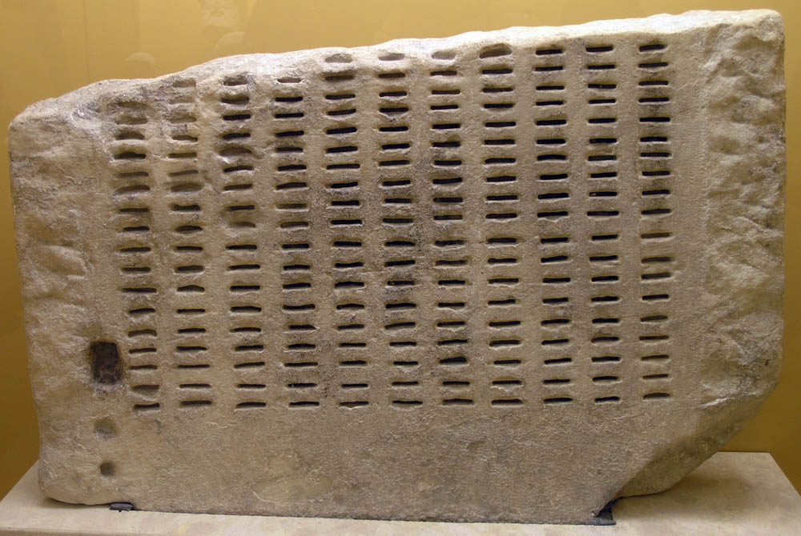

Figure: Kleroterion - a randomization device used by the Athenians during the period of democracy to select citizens to the boule, to most state offices, to the nomothetai, and to court juries.

# Athenian democracy (2)

The Ekklesia (People’s Assembly) became the legislative body of Athens. It was the general meeting of all citizens — males of Athenian origin over the age of 20.

With a few exceptions, all appointments in Athens were made by **lot** or by **rotation** to equalize everyone’s opportunity to hold office.

# Athenian democracy (3)

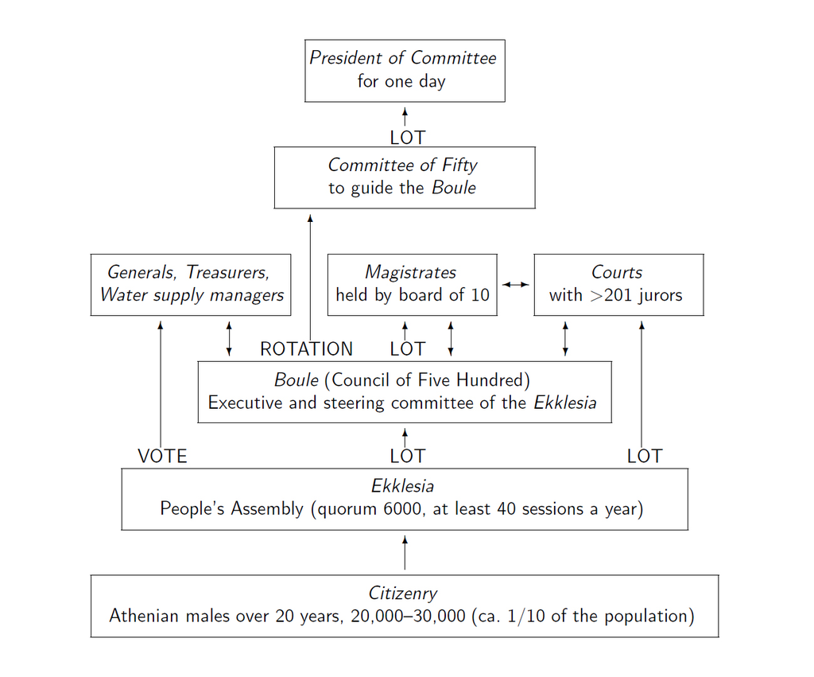

Figure: Athenian democracy - the structure of government (Tangian, 2014)

# City-state and nation state

**A city-state**:

- smaller than a “nation” in the sense of “large sovereign country” and
- may or may not be dominated by all or part of a single “nation” in the sense of a common ethnicity.

**A nation state (or nation-state)**:

- is a country where a distinct cultural or ethnic group (a “nation” or “people”) inhabits a territory and has formed a state (often a sovereign state) that it predominantly governs; It is a more precise concept than “country”, since a country need not have a predominant ethnic group.

# Representative democracy

- In the course of the nineteenth century, **the nation-state displaced the city-state as the appropriate unit for democracy**.
- The institutional innovation that made it possible to extend the bounds of a republic was representation: an innovation that democrats like Madison or Jefferson regarded as **one of the most profound political inventions of all time**.

# Representative democracy (2)

- Constitutional Convention of 1787 (USA) - created a constitution for the first of the large representative democracies. By 1787, the population of the United States was already greater than that of all of Ancient Greece.
- By the middle-and certainly by the end-of the nineteenth century **the idea of democracy in the city-state had been entirely displaced by the idea of representative democracy in the nation-state**.

# Robert Dahl on “realistic” democracy (polyarchy)

**Main features**:

- *elected officials*,
- *free, frequent and fair elections*,
- *freedom of expression*,
- *access to alternative sources of information*,
- *associational autonomy*.

# Larry Diamond on representative democracy

**Main features**:

- a political system for choosing and replacing the government through free and fair elections;
- the active participation of the people, as citizens, in politics and civic life;
- protection of the human rights of all citizens;
- a rule of law, in which the laws and procedures apply equally to all citizens.

# Samuel Huntington on democratic government

“… a twentieth-century political system … [is democratic] … to the extent that its most powerful collective decision makers are selected through fair, honest, and periodic elections in which candidates freely compete for votes and in which virtually all the adult population is eligible to vote.”

“Governments produced by elections may be inefficient, corrupt, shortsighted, irresponsible, dominated by special interests, and incapable of adopting policies demanded by the public good. These qualities may make such governments undesirable but they do not make them undemocratic. Democracy is one public virtue, not the only one …”.

# Democracy and republic

1. The term *republic* today often refers to a representative democracy with an elected head of state, such as a president, serving for a limited term, in contrast to states with a hereditary monarch as a head of state.
2. **James Wilson** - “a republican or democratic” government - “the people at large retain the supreme power”.
3. Today’s modern representative democracies imitate more the Roman Republic than the Greek models because it was a state in which:
- **supreme power was held by the people and their elected representatives**, and
- had an **elected or nominated leader**.

# Democracy and republic (2)

According to *Montesquieu*:

*[R]epublican government is that in which the body, or only a part of the people, is posessed of the supreme power*,

… and thus may be either **a democratic or an aristocratic republic**.

- In other words, republic is the main category of government in which authority rests initially with the populace, but is composed of two subcategories, the democratic if all the people rule or the aristocratic if only a select number of them do.
- Before the establishment of the universal suffrage (XXth century), **only a minority of people were citizens with votes in elections for representatives**.

# Democracy and republic (3)

As for the republican form of government, some emphasize “rule of law”: **John Adams** described a republic as

- *an Empire of Laws, and not of Men*, or as a government in which all men of all classes and interests *are equally subject to the laws*.

# Principles of Free Elections

The election is considered to be ‘**general**’ because all citizens have the right to vote - regardless of gender, income, religion, profession or political beliefs. They usually must, however, be aged 18 or over on election day.

The election is ‘**secret**’ - a voter’s choices in an election or a referendum are both secret and anonymous.

The election is ‘**direct**’ because the voters elect without an intermediate body.

The election is ‘**free**’ because citizens may not be influenced or put under pressure regarding their decision on whom to support.

The election is ‘**equal**’ because each voter is allowed to cast the same numbers of votes.

In fact, it is not usually true that every vote carries the same weight. **We will discuss this important issue later**.

# The growth of universal suffrage in UK

$$**1265**$$

*Parliament established*. It contains 2 chambers. One is ‘the Lords’ - **unelected aristocrats**. The other is ‘the Commons’. These Members of Parliament (MPs) are **smaller landowners and are elected only by male landowners**.

$$**1832**$$

*Great Reform Act*. Before this time only landowners could vote for MPs to sit in the House of Commons. This meant **1 in 7 men could vote**. (440,000 people) After 1832 **the male urban middle classes** gain the vote, and so the electorate increases to 1 in 5 men (650,000 people). (...)

# … The growth of universal suffrage in UK

$$**1867**$$

*Second Reform Act*. This extends the vote to the skilled **urban male working class**. The electorate increases to 1 in 3 men.

$$**1884**$$

*Third Reform Act*. The vote is now given to **working class men in the countryside**. The electorate is now 2 out of 3 men.

$$**1918**$$

*Representation of the People Act*. Almost all men over 21 years old, and women over 30 years old now have the vote.

$$**1928**$$

Effectively **all women and men over 21 now have the right to vote**.

# Electoral fraud

What prevents election from being fair and free?

# Electoral fraud (2)

The electorate may be poorly informed about issues or candidates due to **lack of freedom of the press**, lack of objectivity in the press due to state or corporate control, or lack of access to news and political media.

**Freedom of speech may be limited** by the state, favoring certain viewpoints or state propaganda.

# Electoral fraud (3)

**Electoral fraud involve** e.g. manipulating electoral districts boundaries, exclusion of opposition candidates from eligibility for office, and manipulating thresholds, those in power may arrest or assassinate candidates, outlaw competitors, harass or beat campaign workers, or intimidate voters with violence, tampering with the election mechanism, confusing or misleading voters about how to vote, violation of the secret ballot, tampering with voting machines, destruction of legitimately cast ballots, voter suppression, voter registration fraud, failure to validate voter residency, fraudulent tabulation of results, use of physical force or verbal intimation at polling places, persuading candidates into not standing against them, blackmailing, bribery, carousel voting etc.

# Electoral fraud (4)

**Carousel voting** is a method of vote rigging in elections, used e.g. in Russia and Ukraine. Voters are driven around to cast ballots multiple times. The term "carousel" refers to the circular movement made by the voters, from one polling station to the next, and so on.

# Lecture 2: Electoral systems - methods of selection of partisan (political) and nonpartisan officials (part 1)

# Collective decisions

Voting is a way to make collective decisions, that is, decisions that are made by a group. There are also **other methods to make group decisions** - e.g. consensus, random process, sortition, contest.

# Consensus

**Consensus** is a process for group decision-making. It is a method by which an entire group of people can come to an agreement. The input and ideas of all participants are gathered and synthesized to arrive at **a final decision acceptable to all**.

- In order to reach consensus, it is not necessary that everyone expresses their will or opinion. The distribution of preferences remains unknown.
- But what is **the decision rule**, then?
- The decision-rule is that no one disagrees. To be more precise: consensus means that no one expresses dissent.

# Collective decisions (2)

Consensus may not be efficient way to make decisions when the group of people who try to select the best option is very large. Consensus may take much more time than voting.

# Collective decisions (3)

**In voting**, everyone expresses their will/opinion (in the form of a vote), which means that voting produces certainty regarding the distribution of preferences. The decision rule is applied to this distribution to determine the collective decision.

**For example**, in the case of a simple majority vote, the option with the most votes becomes the collective decision.

There are many different methods of selecting using a vote - we discuss some of them in this course.

# Voting

Voting has been used as a feature of democracy since the 6th century BC, when democracy was introduced by the Athenians.

However, **in Athenian democracy, voting was seen as the least democratic among methods used for selecting public officials, and was little used**, because elections were believed to inherently favor the wealthy and well-known over average citizens.

Assemblies open to all citizens, and **selection by lot** (known as sortition), as well as **rotation of office** seems to be more democratic for Athenians.

# Sortition

**Sortition** (also known as allotment or the drawing of lots) is the selection of decision makers **by lottery**. The decision-makers are chosen as a random sample from a larger pool of candidates.

In ancient Athenian democracy, sortition was the primary method for appointing officials, and its use was widely regarded as a principal characteristic of democracy.

# Voting (2)

One of the earliest recorded elections in Athens was a **plurality vote** that it was undesirable to "win": in the process called **ostracism**, voters chose the citizen they most wanted to exile for ten years.

**Most elections in the early history of democracy were held using plurality voting or some variant**, but as an exception, the state of Venice in the 13th century adopted the system we now know as **approval voting** to elect their Great Council.

# Voting system

Free and fair *elections* are a central feature of, and a neccesery condition for, representative democracy.

An electoral system is a set of rules that determine how elections and referendums are conducted and how their results are determined.

- Electoral systems consist of sets of rules that govern all aspects of the voting process: e.g. how ballots are marked and cast, how do the ballot papers look, how the ballots are counted (voting method), what are magnitudes of voting districtis, are there any formal electoral thresholds of representation used in elections, etc.

# Social choice theory

The study of formally defined voting systems is called **social choice theory** or voting theory, a subfield of political science, economics and mathematics.

**Social choice theory is concerned with the study of group decision making processes.**

# Voting system (2)

A voting system or electoral system is *a winner-selection method* by which voters make a choice between options, often in an election or on a policy referendum.

In the broad sense of the term, the electoral system is a set of laws that regulate electoral competition between candidates or parties or both.

# Voting system (3)

Electoral system comprises three essential elements, namely:

- **electoral formula**, i.e. the method that is used for the *translation* of vote totals into representative seats in the parliament;
- **electoral district magnitude**, i.e. the total number of seats given to each district or constituency; It is a territorial subdivision (area) for electing members to e.g. a legislative body - **votes are counted and transformed into seats at the electoral district level**. Each electoral district is assigned a specific number of seats according to its population (or voting-age population). There are **multi-member districts** (MMD) or **single-member districts** (SMD);
- **ballot type**, i.e. how voters (constituents) cast their votes?, what does a ballot paper look like?
- [an optional element] formal (legal) threshold of representation (not to be confused with the so-called **natural threshold**).

# Voting system (4)

**Electoral formula** is the most important element of a voting system and usually the name of the electoral system is derived from the name of electoral formula.

# Voting system - ballot types

We can distinguish **two types of ballots** - **categorical** (voters are allowed to choose only one candidate or party) and **preferential** (voters can rank each candidate in order of preference).

In some voting systems voters are eligible to use both categorical and preferential vote, e.g. voters choose between parties (categorical) and then rank candidates on the chosen party list.

# Types of voting systems

Electoral systems can be divided into three essential subgroups:

1. majoritarian voting systems (use majoritarian formulas) - e.g. plurality method, Borda count, Instant Runoff (alternative vote),
2. proportional representation voting systems (use proportional formulas) - apportionment methods such as Hare-Hamilton, D’Hondt and Sainte-Lague,
3. mixed voting systems (combine two or more different types of electoral formulas, for example majoritarian and proportional); e.g. German mixed-member proportional system.

# Types of voting systems (2)

A majoritarian electoral system is one in which the candidates or parties that receive the most number of votes win.

There are two general types of majoritarian electoral systems:

1. plurality (or relative majority) electoral systems,
2. absolute majority electoral systems.

# Types of voting systems (3)

In proportional representation systems (PR) we use so-called *divisors* (denoted with *d*) to *proportionally* distribute seats.

The divisor is derived from the *proportionality principle*:
$$\frac{s_i}{S} = \frac{v_i}{V} \forall i$$

Roughly speaking, to obtain a seat in PR, party or candidate have to gain at least as many votes as the value of the *divisor*. The divisor is the minimum number of votes required for a party or candidate to capture a seat.

- So-called *simple or standard divisor* equals **the number of total valid votes divided by the number of available seats**.

**PR methods will be discussed later in detail**.

# Types of voting systems (4)

The idea behind proportional representation is that a **proportion of votes obtained should correspond to the proportion of seats** - the number of seats won by a party or group of candidates is proportionate to the number of votes received.

- For example, under a PR voting system, if 30% of voters support a particular party then roughly 30% of seats will be won by that party.

# Lecture 2b Majoritarian electoral (voting) systems: how to choose the winner/winners using variaties of **plurality** and **absolute majority** systems?

# Majoritarian electoral (voting) systems

The table below presents the distribution of valid preferential votes (e.g.: 5 ballots: ABC, that is, A $\succ$ B $\succ$ C).

Voters were eligible to rank candidates so the table shows detailed preference schedule (distribution of voters’ preferences).

- **Determine the winner/winners of elections employing various majoritarian voting formulas**.

| Ranking | ABC | ACB | BAC | BCA | CAB | CBA |
| --- | --- | --- | --- | --- | --- | --- |
| No. of Votes | 5 | 0 | 2 | 1 | 0 | 4 |

# Plurality Method

With the *plurality method*, the winner is the candidate (or candidates) with the highest number of votes.

If there is more than one seat to obtain in electoral district, say *n*, the *n* candidates with the most votes are declared winners.

In the example, if there is only one seat available, **the winner is the candidate A**.

# Plurality method in SMD and MMD (a few well-known variants)

- FPTP (First-Past-the-Post),
- MNTV (Multimember non-transferable vote, Block vote),
- SNTV (Single non-transferable vote),
- LV (Limited vote),
- PBV (Party block vote).

# FPTP

A first-past-the-post (FPTP) voting method is one in which voters indicate on a ballot the candidate of their choice, and the candidate (single-member electoral districts (SMD) are used) who receives the most votes wins. This is sometimes described as winner takes all.

# Borda Count

- Named for the 18th-century French mathematician and political scientist Jean-Charles de Borda.

Each voter ranks the candidates. If there are $n$ candidates, then $n$ points are assigned to the first choice for each voter, $n-1$ points for the next choice, and so on (we can also assign $n-1$ points for the first choice, $n-2$ for the second and ... 0 for the last choice).

The points for each candidate are added and the candidate who received the largest number of points is declared the winner.

# Borda Count (2)

Who is selected as the winner if we employ *Borda count*?

- Candidate B is the winner (27 points).

For example: the option A gets $5*3 + 2*2 + 1*1 + 4*1 = 24$ points.

# Instant Runoff Method

**Instant-runoff voting** (IRV), alternative vote (AV), or transferable vote is an electoral system used to elect a single winner from a field of more than two candidates.

- It is a preferential voting system in which voters rank the candidates in order of preference rather than voting for a single candidate. Ballots are initially distributed based on each elector’s first preference.
- **If a candidate secures more than half of votes cast, that candidate wins**. Otherwise, the candidate with the fewest votes is eliminated. Ballots assigned to the eliminated candidate are recounted and assigned to those of the remaining candidates who rank next in order of preference on each ballot. This process continues until one candidate wins by obtaining more than half the votes.

# Instant Runoff Method (2)

Employing the preference schedule:

| Ranking | ABC | ACB | BAC | BCA | CAB | CBA |
| --- | --- | --- | --- | --- | --- | --- |
| No. of Votes | 5 | 0 | 2 | 1 | 0 | 4 |

No candidate captured the absolute majority (i.e. 7 first preferences), so **we drop the weakest one and transfer his or her votes to the rest according to the second preferences**:

| Ranking | AC | AC | AC | CA | CA | CA |
| --- | --- | --- | --- | --- | --- | --- |
| No. of Votes | 5 | 0 | 2 | 1 | 0 | 4 |

# Instant Runoff Method (3)

**Consider another example**. Now we have:

| Ranking | ABCD | BACD | BCAD | DCAB | CBAD |
| --- | --- | --- | --- | --- | --- |
| No. of Votes | 4 | 2 | 1 | 2 | 5 |

- Eliminating the candidate D we get:

| Ranking | ABC | ACB | BAC | BCA | CAB | CBA |
| --- | --- | --- | --- | --- | --- | --- |
| No. of Votes | 4 | 0 | 2 | 1 | 2 | 5 |

- The majority equals **8**, so we still do not have the winner. We have to drop the second candidate, namely B.

| Ranking | AC | AC | AC | CA | CA | CA |
| --- | --- | --- | --- | --- | --- | --- |
| No. of Votes | 4 | 0 | 2 | 1 | 2 | 5 |

- **Can we declare the winner for now?**

# The method of pairwise comparisons

In the pairwise comparison voting system, the voters rank the candidates by making a series of comparisons in which each candidate is compared to each of the other candidates.

For example, if choice A is preferred to B, then A receives 1 point. If the candidates tie, each receives 0.5 point. The candidate with the most points is declared the winner.

# The method of pairwise comparisons - example

Recall the following distribution of votes:

| Ranking | ABC | ACB | BAC | BCA | CAB | CBA |
| --- | --- | --- | --- | --- | --- | --- |
| No. of Votes | 5 | 0 | 2 | 1 | 0 | 4 |

Who is the winner in Pairwise Comparison Method?

- **A over B**: 5 voters;
- **B over A**: 7 voters;
- **C over A**: 5 voters;
- **A over C**: 7 voters;
- **B over C**: 8 voters;
- **C over B**: 4 voters;

Thus, B beats A, A beats C, B beats C.

- Then, **B** obtains **2** points, **A** obtains **1** point and **C** obtains **0** points.
- **The winner is the candidate B**.

# Runoff Method (the two-round majority system)

With the **runoff method**, candidates are expected to gain a **majority of votes** (or absolute majority) to be declared the winner. By majority of votes, we mean receiving more than 50% of total votes. If no candidate receives the required number of votes (an absolute majority), then all but the two candidates receiving the most votes, are eliminated, and a second round of voting (runoff) occurs.

# Runoff Method (2)

- In our example we have **12 voters**, therefore the majority is equal to 7, but examining preference table we can see that **there is no majority winner**.
- Let us **eliminate the weakest candidate**, then **constituents vote again** (for simplicity, we assume that their preference schedule is the same as during the first round of election, and also that voters supporting B do not vote.).

| Ranking | AC | AC | AC | CA | CA | CA |
| --- | --- | --- | --- | --- | --- | --- |
| No. of Votes | 5 | 0 | 2 | 1 | 0 | 4 |

- **The winner is A**.

# Approval Voting

The approval voting method allows each voter to cast one vote for each candidate who **meets his or her approval**.

The candidate with the most votes is declared the winner. Approval voting has also been called *set voting* because voters vote for whichever set of candidates they prefer versus the candidates they don’t vote for.

# Some variaties of the *plurality* majoritarian and the *absolute* majority voting systems - usage

|  | Method | Usage |
| --- | --- | --- |
| 1 | First-Past-the-Post | e.g. UK, USA, Canada, Poland |
| 2 | Two-round majority system | e.g. lower house elections in France |
| 3 | Instant Runoff | e.g. Australia, Oscar for Best Picture |
| 4 | Borda count | Nauru |
| 5 | SNTV | e.g. Japan |
| 6 | Limited vote | e.g. Spain |
| 7 | Block vote | e.g. Poland before 2011 |
| 8 | Party block vote | Singapore |
| - | - | - |

# Voters’ preferences - voting system - election result

Assuming that a voters’ preference distribution does not change, switching between various voting methods may change the result of election - the so-called **mechanical effect** of a voting system.

The voting system affects the *format* and the *mechanism* of party systems.

- **There is also the *psychological* effect that will be discussed later**.

# Kenneth Arrow on voting systems and election results

Arrow shows that the result of any **preference-aggregation mechanism** (any voting system) depends upon the mechanism itself as well as on the preferences of the voters:

- **same mechanism, different preferences**: (potentially) different outcome of elections;
- **same preferences, different mechanism**: (potentially) different outcome of elections.

# K. Arrow’s fairness criteria (1)

What would it take for a voting method to at least be a fair voting method?

Kenneth Arrow set forth a minimum set of requirements that we call **Arrow’s fairness criteria**:

# K. Arrow’s fairness criteria (2)

- The **majority criterion**. A majority candidate (i.e., a candidate with a majority of the first place votes) should always be the winner.
- The **Condorcet criterion**. A Condorcet candidate (i.e., a candidate that beats each of the other candidates in a pairwise comparison) should always be the winner.

# Condorcet candidate

A candidate preferred by a majority of the voters over every other candidate when the candidates are compared in head-to-head comparisons is called a Condorcet candidate (named after the Marquis de Condorcet, an eighteenthcentury French mathematician and philosopher).

# K. Arrow’s fairness criteria (3)

- The **monotonicity criterion**. If candidate X is the winner, then X would still be the winner had a voter ranked X higher in his preference ballot. (In other words, a voter should not be able to hurt the winner by moving him up in his ballot.)
- The **independence-of-irrelevant-alternatives** (**iia** or **IIA**) criterion. If candidate X is the winner, then X would still be the winner had one or more of the irrelevant alternatives (i.e., losing candidates) not been in the race. (In other words, the winner should not be hurt by the elimination from the election of irrelevant alternatives.)

# Borda count violates the majority criterion

| No. of voters | 6 | 2 | 3 |
| --- | --- | --- | --- |
| 1 | A | B | C |
| 2 | B | C | D |
| 3 | C | D | B |
| 4 | D | A | A |

Table shows the preference schedule for a small election.

The majority candidate in this election is **A with 6 out of 11 first-place votes**.

Under the *Borda count* method, **the winner is B** (32 points to A’s 29 points).

# The plurality method (*first-past-the-post* (FPTP)) violates the Condorcet criterion

| No. of voters | 49 | 48 | 3 |
| --- | --- | --- | --- |
| 1 | *R* | **H** | F |
| 2 | **H** | S | **H** |
| 3 | F | O | S |
| 4 | O | F | O |
| 5 | S | *R* | *R* |

- **Under the plurality method the winner of the election is “R”**, with 49 first-place votes.
- This is a rather bad outcome, as there are 51 voters that have “R” as their last choice.
- By contrast, “H” has 48 first-place votes and 52 second place votes - a very good result.
- If we compare “H” with any other candidate on **a head-to-head** basis, “H” is always the preferred choice.
- For example, there are 51 votes for “H” (48 from the second column plus the 3 votes in the last column) versus 49 votes for “R”.

# Plurality-with-elimination (Instant Runoff) violates the monotonicity criterion

- Before:

| No. of voters | 7 | 8 | 10 | 2 |
| --- | --- | --- | --- | --- |
| 1 | A | B | C | **A** |
| 2 | B | C | A | C |
| 3 | C | A | B | B |

TS = 27,

Absolute majority = 14.

- B is eliminated.

**The winner is C**.

- … and after the change (2 voters decide to move **C** up):

| No. of voters | 7 | 8 | 10 | 2 |
| --- | --- | --- | --- | --- |
| 1 | A | B | C | C |
| 2 | B | C | A | **A** |
| 3 | C | A | B | B |

- A is eliminated.
- **The winner is B**.

# Borda count violates IIA

| No. of voters | 4 | 3 | 9 |
| --- | --- | --- | --- |
| 1 | A | A | B |
| 2 | B | C | A |
| 3 | C | B | C |

**Assumption**: we assign $n-1$ points for the first choice, $n-2$ for the second and ... 0 for the last choice.

- *Borda count* results: A: 23 p., B: 22 p., C: 3 points.

# Borda count violates IIA (2)

- Suppose that 3 voters decide that candidate C is even worse than they thought before and should be dropped to the bottom of their ballots. **Note that the relative positions of A and B have not changed**.

| No. of voters | 4 | **3** | 9 |
| --- | --- | --- | --- |
| 1 | A | A | B |
| 2 | B | B | A |
| 3 | C | C | C |

With C at the bottom, the winner is **B** (25 point).

We call C an *irrelevant alternative* in ranking A and B.

# Plurality method violates the IIA

In a plurality voting system 7 voters rank 3 alternatives (A, B, C).

- 3 voters rank (A$\succ$B$\succ$C)
- 2 voters rank (B$\succ$A$\succ$C)
- 2 voters rank (C$\succ$B$\succ$A)

In an election, initially only A and B run: B wins with 4 votes to A’s 3, but **the entry of C into the race makes A the new winner**.

- The relative positions of A and B are reversed by the introduction of C, an “irrelevant” alternative.

# Implications of the Arrow’s impossibility theorem

The theorem implies that:

**Each of the voting methods can be made to violate at least one of the fairness criteria presented above** - in particular IIA.

IIA criterion is sometimes criticised for being too strong to be satisfied by any voting method.

**There is no perfect voting method.**

# Summary of violations of the fairness criteria

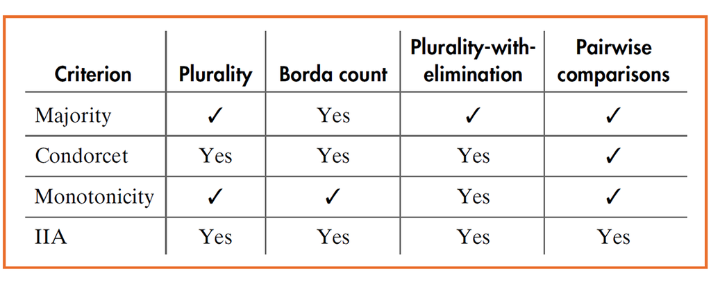

Figure: Summary of violations of the fairness criteria. “Yes” indicates that the method violates the criterion (Tannenbaum 2014).

# Lecture 3: Electoral systems - methods of selection of partisan (political) and nonpartisan officials (part 2) - Proportional representation - apportionment methods

# Types of apportionment methods

Remark: Proportional representation requires multi-member districts (in practice, at least 3 seats per constituency).

1. **Highest averages methods**
- D’Hondt
- Sainte-Lague
- …
2. **Largest remainders methods**
- Hare-Hamilton
- …

# Apportionment methods

Apportionment methods are used in order to satisfy the principle of proportional representation.

- Various apportionment methods are used to e.g.: 1) **distribute seats among parties**; 2) **assign seats to electoral districts in proportion to electoral districts’ populations**.

# Apportionment methods (2)

In order to distribute the number of seats won by a party or group of candidates in proportion to the number of votes received, we make use of the following **proportion**:

$$\frac{s_i}{S} = \frac{v_i}{V} \forall i$$
where:

$v_i$ = the number of valid votes for i-th party;

$s_i$ = the number of seats assigned to i-th party;

$TV$ or $V$ = the total number of valid votes;

$TS$ or $S$ = the total number of available seats.

# Apportionment methods (3)

Transforming the equation above we obtain:

$$s_i = v_i \frac{S}{V} \text{ or equivalently } s_i = \frac{v_i}{\frac{V}{S}} = \frac{v_i}{d}$$

$d = \frac{V}{S}$ is called **a standard divisor**.

Assume we have $S = 10, V = 100, v_1 = 40$. Then, we get
$$\frac{\text{?}}{10} = \frac{40}{100}$$

Of course, “?” equals 4.

# Standard quota

$$q_i = \frac{v_i}{\frac{V}{S}}$$

**The standard quota** of a party ($q_i$) (sometimes called the fair quota) is the exact fractional number of seats that the party would get if fractional seats were allowed.

# Apportionment methods - what does it mean that two quantities (*votes and seats*) are in proportion (proportional)

In general, **proportion** says that two ratios (or fractions) are equal. For example:

$$\frac{1}{2} = \frac{2}{4}$$

**1-out-of-2** is equal to **2-out-of-4**

The ratios are the same, so they are **in proportion** (are proportional). When things are in proportion, then their relative sizes are the same.

# Apportionment methods (5)

Let us use the formula above to distribute seats from the example below.

There are **12 seats** to distribute in an electoral district. **6 parties** participate in elections. The table below shows the distribution of valid votes in the district.

| $i$ | $v_i$ |
| --- | --- |
| 1 | 26000 |
| 2 | 19000 |
| 3 | 18500 |
| 4 | 16000 |
| 5 | 10000 |
| 6 | 3700 |
| $\sum$ | 93200 |

# Apportionment methods (6)

Let us use the formula above to distribute seats from the example below.

Then, we can write

$$q_i = s_i^{*} = \frac{v_i}{\frac{93200}{12}} = \frac{v_i}{7766.66667}$$

# Apportionment methods (7)

We get:

| *i* | $v_i$ | $q_i$ | $[q_i] = s_i$ |
| --- | --- | --- | --- |
| 1 | 26000 | 3.35 | 3 |
| 2 | 19000 | 2.45 | 2 |
| 3 | 18500 | 2.38 | 2 |
| 4 | 16000 | 2.06 | 2 |
| 5 | 10000 | 1.29 | 1 |
| 6 | 3700 | 0.48 | 0 |
| $\sum$ | 93200 |  | 10 [< 12 (**!**)] |

# Hamilton (Hare) Method

In the previous example we tried to distribute seats rounding the so-called standard quota of seats to the nearest integer (whole number). **Unfortunately, this approach often fails**.

To resolve the problem of rounding that emerged in the previous example, we employ one of the apportionment methods, for instance Largest Remainders Methods (LRM).

# Hamilton (Hare) Method (2)

**Hamilton method** is the most popular LRM. We employ this method to resolve the problem of rounding in proportional division of seats.

- **How we handle rounding is a large part of distinguishing apportionment methods**.

# Hamilton (Hare) Method (4)

Employing Hamilton method we finally get the following distribution:

| *i* | $v_i$ | $q_i$ | $\lfloor q_i \rfloor$ | $r_i = q_i - \lfloor q_i \rfloor$ | $s_i$ |
| --- | --- | --- | --- | --- | --- |
| 1 | 26000 | 3.35 | 3 | 0.35 | 3 |
| 2 | 19000 | 2.45 | 2 | 0.45 | 2+1 |
| 3 | 18500 | 2.38 | 2 | 0.38 | 2 |
| 4 | 16000 | 2.06 | 2 | 0.06 | 2 |
| 5 | 10000 | 1.29 | 1 | 0.29 | 1 |
| 6 | 3700 | 0.48 | 0 | 0.48 | 0+1 |
| $\sum$ | 93200 |  | 10 |  | 12 |

# Jefferson-d’Hondt method

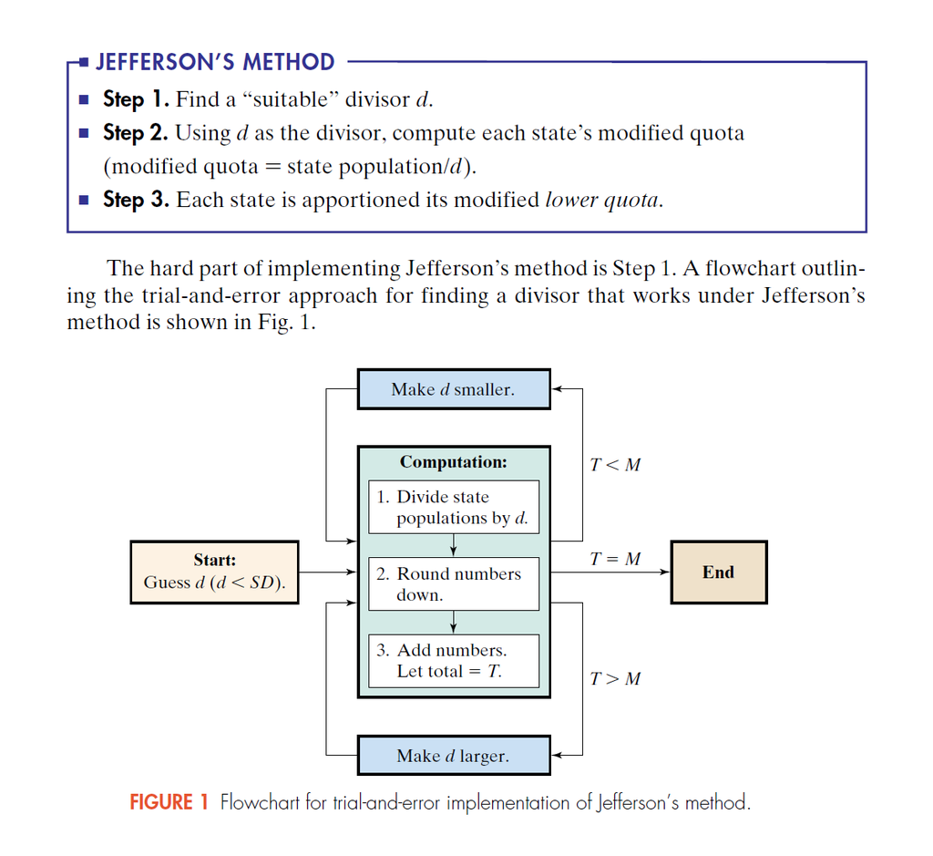

Figure: Jefferson-d’Hondt algorithm (Tannenbaum 2014).

# Webster - Sainte-Lague method

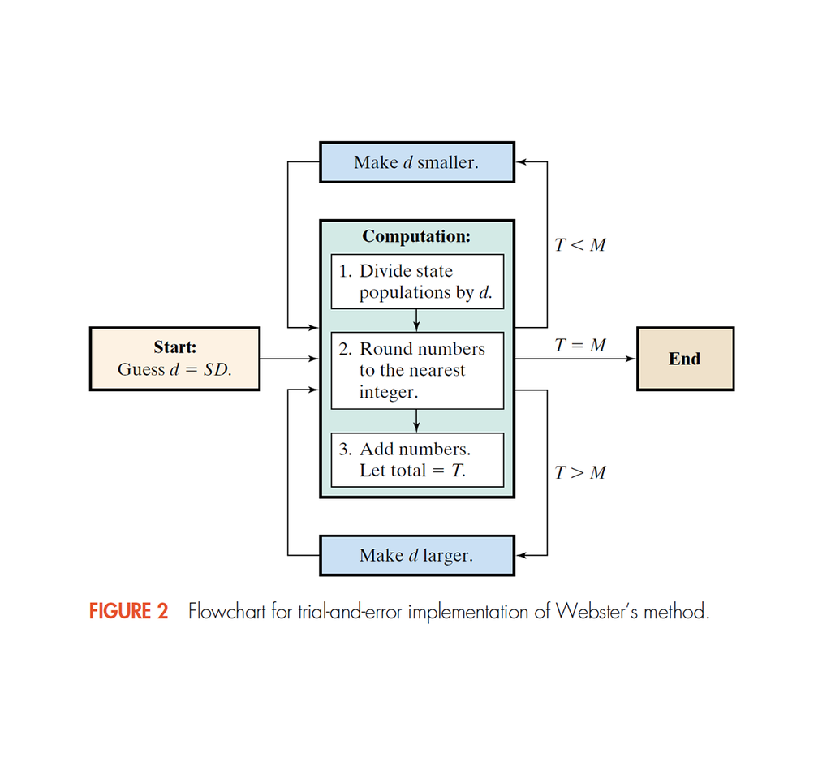

Figure: Webster - Sainte-Lague algorithm (Tannenbaum 2014).

# Apportionment methods - examples

**Link**: https://docs.google.com/spreadsheets/d/1QslIHty8AT_R7nLXiliYg4QQE2f0b7WqjWaG-eKFziw/edit?usp=sharing

# A *unification* bonus - example

Forming an electoral alliance (a pre-election coalition), can be beneficial for the coalition and for the parties within the alliance. The alliance can get more seats than if the parties within it run for seats separately - this is because some voting methods such as D’Hondt are *superadditive*.

**Link**: https://docs.google.com/spreadsheets/d/1b3etzZhjIKbVfXKrehmjRiR-l4zIkjEyOFsH87DqfgA/edit?usp=sharing

Remark: Sainte-Lague is not *superadditive*.

# The **quota rule** and **paradoxes of apportionment** methods

# Lecture 4: Electoral systems - methods of selection of partisan (political) and nonpartisan officials (part 3)

# Electoral districts - definition

Electoral district is a territorial subdivision for electing members to a legislative body.

# Advantages of delimiting electoral districts (1)

1. Geographic link between constituent and representative - electoral districts improve the accountability of representatives to their voters. Electoral districts link elected representatives to a smaller, geographically-defined, constituency. This allows voters to hold specific representatives accountable.

As multiple-member districts are made larger, this link is weaker. In party list PR systems without delineated districts, such as the Netherlands and Israel, the geographic link between representatives and their constituents is considered extremely weak.

# Advantages of delimiting electoral districts (2)

2. Electoral districts can ensure broader geographic representation in parliament. Electoral districts guarantee a geographic diversity in the legislative assembly. This generally also means that more attention is accorded to regional issues and to constituency service.

# Advantages of delimiting electoral districts (3)

3. Electoral districts would permit the use of an open party list (Open-list proportional representation systems) – difficult to manage administratively with a single national constituency, because of too many candidates (e.g. 460 in Polish lower house election)

**However, the most compelling argument against delimitation is that a constituency-based system can produce substantial electoral disproportionality - in PR systems, the decrease in district magnitudes elicits the rise in electoral disproportionality**.

# Ballot types - a few examples

# Ballot types (2)

1. FPTP

# Ballot types (3)

2. STV

…

# Ballot types (4)

3. Closed-list PR

…

# Ballot types (5)

4. OLPR

…

# Mechanical and psychological effects of voting systems

Voting systems affect the results of elections. Scholars distinguish *mechanical* and *psychological* effects of electoral systems.

**Mechanical** effect is the result of mathematical properties of a voting system; how electoral systems affect the way votes are transformed into seats in a parliament.

# Mechanical and psychological effects of voting systems (2)

- The psychological effect is, **according to M. Duverger**, the anticipation by voters and political actors of the mechanical effect.
- Actors predict the distortion entailed by the transformation of votes into seats; they adapt their behaviour so as to make votes count (Cox 1997). This is:
- **strategic voting** on the side of voters, and
- **strategic entry** on the side of parties and candidates.

# Endogeneity in studies on electoral systems

- Endogeneity (*endogeneity*) - the error term of a statistical model is correlated with predictors.
- It is difficult to study the *mechanical* and *psychological* effects of a voting system separately; **anticipated** *mechanical* effects affect *psychological* factors.
- Basic variables explaining electoral disproportionality, that is, **district magnitude** and **voting method** correlate with **the number of competing parties** and with the **voters’ preferences distribution**.

# Mechanical and psychological effects of voting systems (3)

- **Duverger’s ‘law’** - plurality rule elections structured within single-member districts tend to favor a **two-party system** and the proportional representation tend to **multipartism**.
- **Riker’s proposition**

Plurality formulas are always associated with two-party competition except where strong local minority parties exist.

# Mechanical and psychological effects of voting systems (3)

- The **spoiler effect** is the effect of vote splitting between candidates or ballot questions with similar ideologies. One spoiler candidate’s presence in the election draws votes from a major candidate with similar politics thereby causing a strong opponent of both or several to win. The minor candidate causing this effect is referred to as a spoiler.
- In plurality voting if two similar candidates split a majority of the vote, in a plurality election, a candidate strongly opposed by a majority of the voters can be elected. This violates the important criteria of majority rule.

# Mechanical and psychological effects of voting systems (4)

The electorate reacts to the electoral system by strategically defecting from their preferred party to a more viable party. Voter-centric psychological effects – strategic voting – have become the focal point of electoral research in recent years.

Strategic voting occurs under different electoral formulas, suggesting that voters anticipate the mechanical effects of electoral rules in various settings.

District magnitude impacts party system size - this relationship is conditioned by heterogeneity. The more seats to be filled in a constituency, the more parties are competing, the more parties receive votes and the more parties gain seats.

# Mechanical effect and electoral disproportionality

Important, ‘mechanical’ predictors:

- district magnitude,
- electoral formula,
- formal threshold of representation.

[figure not shown]

Read more e.g.: https://www.sciencedirect.com/science/article/pii/S026137941730570X

# Measuring electoral disproportionality

$$Ghi = \sqrt{\frac{1}{2}\sum(s_i/TS-v_i/TV)^2}$$
where: $s_i =$ the fraction of seats assigned to *i*-th party; $v_i =$ the fraction of votes casted for *i*-th party.

# A unification bonus (a coalition bonus)

Numerical example:

https://docs.google.com/spreadsheets/d/1b3etzZhjIKbVfXKrehmjRiR-l4zIkjEyOFsH87DqfgA/edit?usp=sharing

# Mechanical effects of apportionment methods

Numerical example:

https://docs.google.com/spreadsheets/d/1QslIHty8AT_R7nLXiliYg4QQE2f0b7WqjWaG-eKFziw/edit?usp=sharing

# Lecture 4: Gerrymandering and malapportionment

# Gerrymandering

[figure not shown]

Figure: Gerrymandering.

# Malapportionment

Equality of voters:

$$\frac{v_1}{s_1} = \frac{v_2}{s_2} = \text{ ... } = \frac{v_i}{s_i}$$

$$\frac{s_i}{TS} = \frac{v_i}{TV} \forall i$$

where:

- $TV$ = a total number of inhabitants or eligible voters;
- $TS$ = a total number of seats to be apportioned;
- $v_i$ = a number of inhabitants or eligible voters in the $i-$th district;
- $s_i$ = a number of seats to be assigned to the $i$-th district.

# *Ideal* population

The ‘ideal’ population ($i$-th constituency) $= \tilde{v_i} = \frac{TV}{TS} \times s_i$

For SMD, the ‘ideal’ population equals the so-called standard divisor (i.e. $\frac{TV}{TS}$).

# (…)

…